# Covid exploration

Yiwen Liu

This notebook contains some data exploration for COVID-19 using the data published in Feb 2020, which may help you get started. You do *not* have to use it. Note below code may change frequently.

## Import JHU SSE data on GitHub into R

```r
library(tidyverse)
confirmed=read_csv(file="time_series_covid19_confirmed_US.csv", show_col_types = FALSE)
deaths=read_csv("time_series_covid19_deaths_US.csv", show_col_types = FALSE)
```

## Tidy data

Tidy data into the long format. `pivot_longer` is the modern version of `gather` function in dplyr.

```r
confirmed_long <- confirmed %>%
  select(-c(UID:code3, Country_Region, Combined_Key)) %>%
  pivot_longer(-(FIPS:`Long_`),
               names_to = "Date",
               values_to = "confirmed") %>%
  mutate(Date = (mdy(Date))) # convert string to date-time
confirmed_long
```

```
## # A tibble: 3,298,554 × 7
##     FIPS Admin2  Province_State   Lat Long_ Date       confirmed
##    <dbl> <chr>   <chr>          <dbl> <dbl> <date>         <dbl>
##  1  1001 Autauga Alabama         32.5 -86.6 2020-01-22         0
##  2  1001 Autauga Alabama         32.5 -86.6 2020-01-23         0
##  3  1001 Autauga Alabama         32.5 -86.6 2020-01-24         0
##  4  1001 Autauga Alabama         32.5 -86.6 2020-01-25         0
##  5  1001 Autauga Alabama         32.5 -86.6 2020-01-26         0
##  6  1001 Autauga Alabama         32.5 -86.6 2020-01-27         0
##  7  1001 Autauga Alabama         32.5 -86.6 2020-01-28         0
##  8  1001 Autauga Alabama         32.5 -86.6 2020-01-29         0
##  9  1001 Autauga Alabama         32.5 -86.6 2020-01-30         0
## 10  1001 Autauga Alabama         32.5 -86.6 2020-01-31         0
## # … with 3,298,544 more rows
## # ℹ Use `print(n = ...)` to see more rows
```

```r
death_long <- deaths %>%
  select(-c(UID:code3, Country_Region, Combined_Key)) %>%
  pivot_longer(-c(FIPS:`Long_`, Population),
               names_to = "Date",
               values_to = "death") %>%
  mutate(Date = mdy(Date))
death_long
```

```
## # A tibble: 3,301,896 × 8
##     FIPS Admin2  Province_State   Lat Long_ Population Date       death
##    <dbl> <chr>   <chr>          <dbl> <dbl>      <dbl> <date>     <dbl>
##  1  1001 Autauga Alabama         32.5 -86.6      55869 2020-01-22     0
##  2  1001 Autauga Alabama         32.5 -86.6      55869 2020-01-23     0
##  3  1001 Autauga Alabama         32.5 -86.6      55869 2020-01-24     0
##  4  1001 Autauga Alabama         32.5 -86.6      55869 2020-01-25     0
##  5  1001 Autauga Alabama         32.5 -86.6      55869 2020-01-26     0
##  6  1001 Autauga Alabama         32.5 -86.6      55869 2020-01-27     0
##  7  1001 Autauga Alabama         32.5 -86.6      55869 2020-01-28     0
##  8  1001 Autauga Alabama         32.5 -86.6      55869 2020-01-29     0
##  9  1001 Autauga Alabama         32.5 -86.6      55869 2020-01-30     0
## 10  1001 Autauga Alabama         32.5 -86.6      55869 2020-01-31     0
## # … with 3,301,886 more rows
## # ℹ Use `print(n = ...)` to see more rows
```

```r
ncov_tbl <- confirmed_long %>%
  left_join(death_long) %>%
  rename(fips=FIPS)
  #pivot_longer(c(confirmed,death),
  #             names_to = "Case",
  #             values_to = "Count")
ncov_tbl %>% print(width = Inf)
```

```
## # A tibble: 3,298,554 × 9
##     fips Admin2  Province_State   Lat Long_ Date       confirmed Population
##    <dbl> <chr>   <chr>          <dbl> <dbl> <date>         <dbl>      <dbl>
##  1  1001 Autauga Alabama         32.5 -86.6 2020-01-22         0      55869
##  2  1001 Autauga Alabama         32.5 -86.6 2020-01-23         0      55869
##  3  1001 Autauga Alabama         32.5 -86.6 2020-01-24         0      55869
##  4  1001 Autauga Alabama         32.5 -86.6 2020-01-25         0      55869
##  5  1001 Autauga Alabama         32.5 -86.6 2020-01-26         0      55869
##  6  1001 Autauga Alabama         32.5 -86.6 2020-01-27         0      55869
##  7  1001 Autauga Alabama         32.5 -86.6 2020-01-28         0      55869
##  8  1001 Autauga Alabama         32.5 -86.6 2020-01-29         0      55869
##  9  1001 Autauga Alabama         32.5 -86.6 2020-01-30         0      55869
## 10  1001 Autauga Alabama         32.5 -86.6 2020-01-31         0      55869
##    death
##    <dbl>
##  1     0
##  2     0
##  3     0
##  4     0
##  5     0
##  6     0
##  7     0
##  8     0
##  9     0
## 10     0
## # … with 3,298,544 more rows
## # ℹ Use `print(n = ...)` to see more rows
```

## Mapping US counties

Some useful resources for mapping:  
- The book [*Geocomputation with R*](https://geocompr.robinlovelace.net). Especially [Chapter 8 Making Maps with R](https://geocompr.robinlovelace.net/adv-map.html).  
- The book [*An Introduction to Spatial Analysis and Mapping in R*](https://bookdown.org/lexcomber/brunsdoncomber2e/).

### The county map

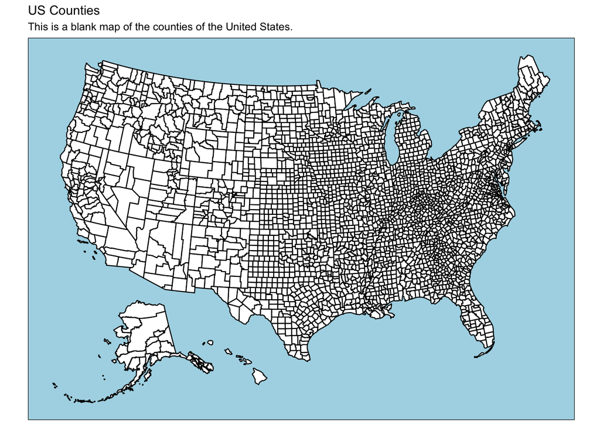

```r
library(usmap)
library(ggplot2)

plot_usmap(regions = "counties") +
  labs(title = "US Counties",
       subtitle = "This is a blank map of the counties of the United States.") +
  theme(panel.background = element_rect(color = "black", fill = "lightblue"))
```

### Add values to map

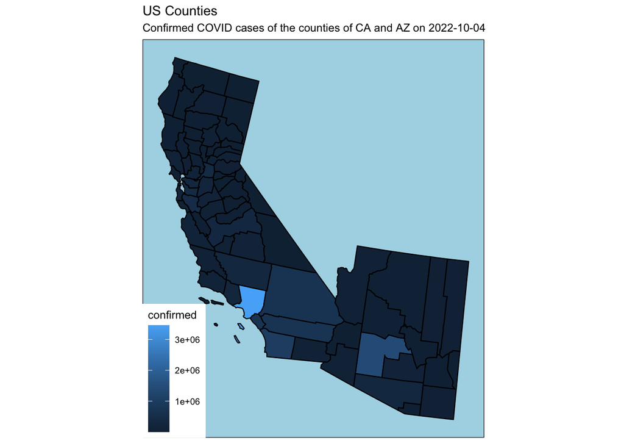

```r
most_recent <- ncov_tbl %>%
  filter(Date=="2022-10-04")

plot_usmap(data=most_recent, values="confirmed", include = c("CA", "AZ")) +
  labs(title = "US Counties",
       subtitle = "Confirmed COVID cases of the counties of CA and AZ on 2022-10-04") +
  theme(panel.background = element_rect(color = "black", fill = "lightblue"))
```

## Animation

Resources about making animations in R:  
- [gganimate](https://gganimate.com/index.html) package.  
- Section 8.3 of [Geomcomputation with R](https://geocompr.robinlovelace.net/adv-map.html#animated-maps).

Plot the date at all time points (this takes long, a couple minutes):

```r
library(gganimate)
ncov_tbl <- ncov_tbl %>%
  mutate(logconfirmed=if_else(confirmed==0, 0, log(confirmed)))
```

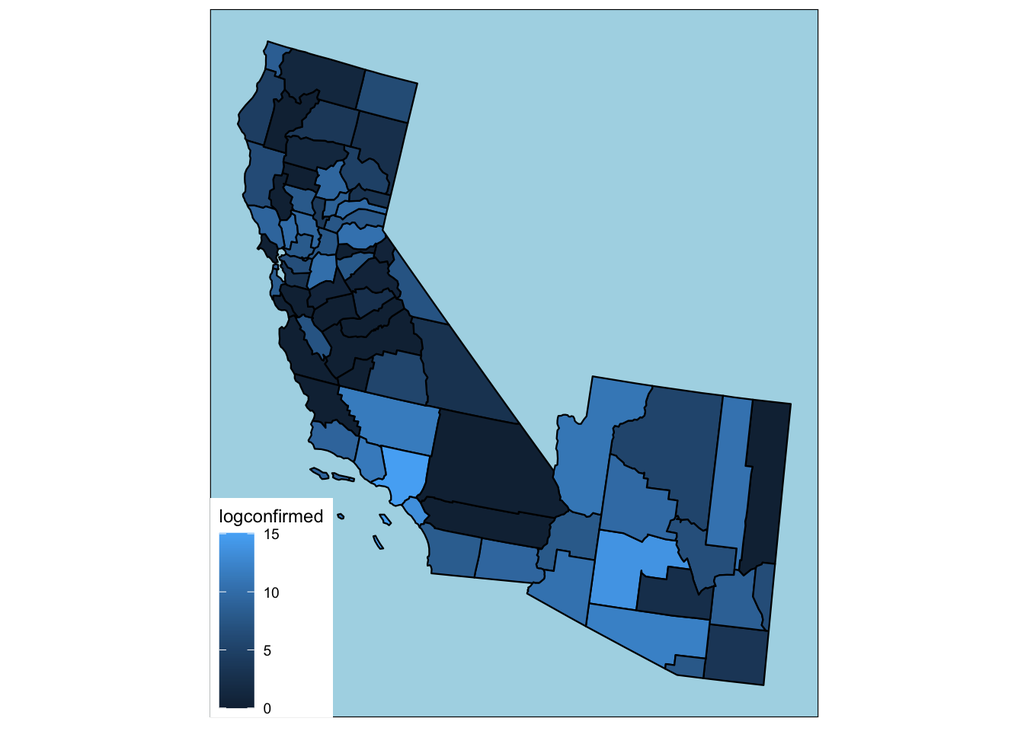

```r
basemap <- plot_usmap(data=ncov_tbl, values="logconfirmed", include = c("CA", "AZ")) +
  theme(panel.background = element_rect(color = "black", fill = "lightblue"))
basemap
```

Then to that plot I am going to use `labs()` to add a title that will count up each date and add `transition_time(Date)`, which will make a separate plot for each day that can be animated together.

```r
library(gifski)
num_date <- max(ncov_tbl$Date) - min(ncov_tbl$Date) + 1
anim <- basemap +
  transition_time(Date) +
  labs(title = "Confirmed Cases", subtitle = "Date: {frame_time}")
animate(anim, renderer = gifski_renderer())
anim_save("confirmed_anim.gif")
```

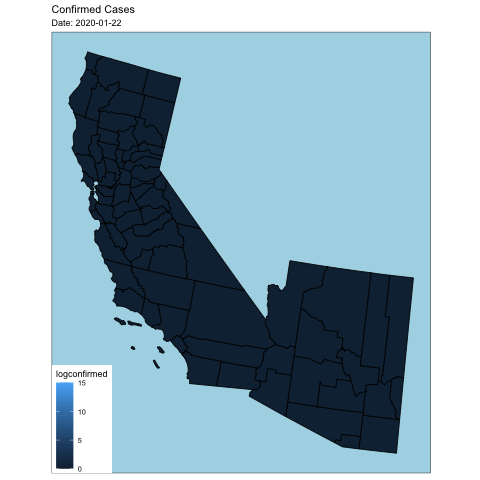